# Modulo 8 : Genómica con R

## Informe de calidad multiqc

Para generar un informe de calidad consolidado utilizando MultiQC, se utiliza el siguiente código:

```r
qc_report(qc.dir, result.file = "results/multiqc/",
          experiment = "Mycoplasma")
```

Este código genera un informe de calidad consolidado en el directorio `results/multiqc/` utilizando la información de calidad previamente generada por FastQC.

Además, se muestran ejemplos de cómo realizar varios tipos de análisis y visualizaciones de calidad utilizando la biblioteca `qc_report`. Estos ejemplos incluyen el análisis de contenido de GC, calidad de secuencia base por base, duplicación de secuencias y más.

```r
qc <- qc_read("results/SRR15616379_1_fastqc.zip")
```

```
## Reading: results/SRR15616379_1_fastqc.zip
```

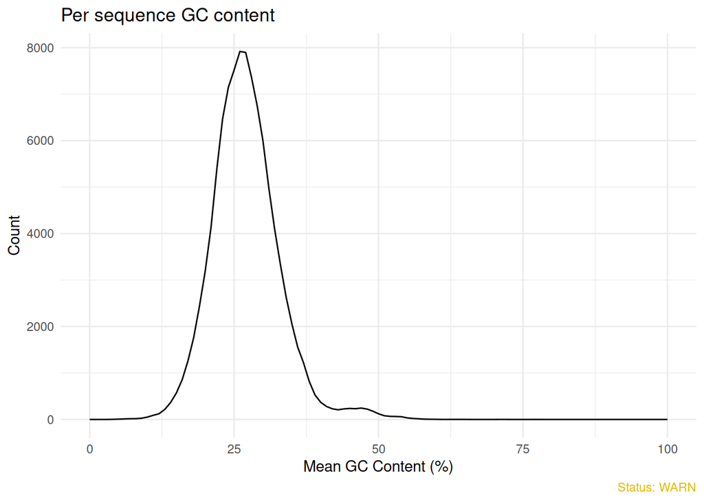

```r
qc_plot(qc, "Per sequence GC content")
```

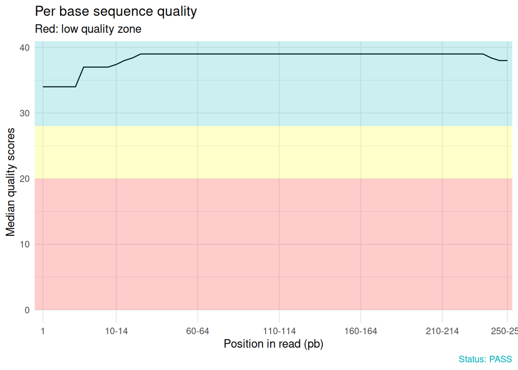

```r
qc_plot(qc, "Per base sequence quality")
```

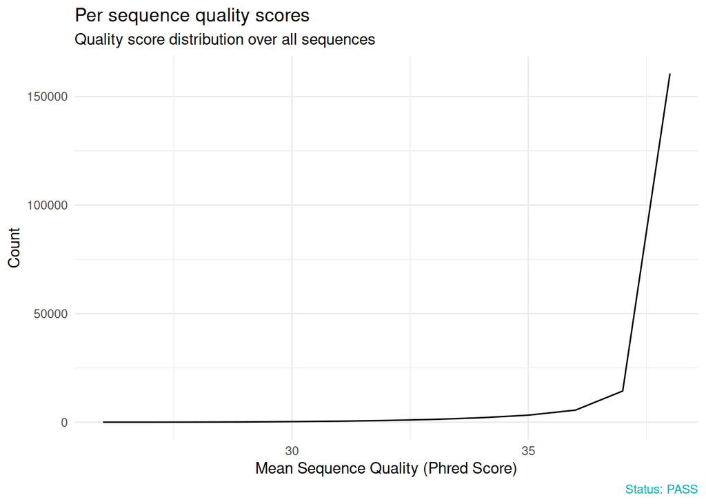

```r
qc_plot(qc, "Per sequence quality scores")
```

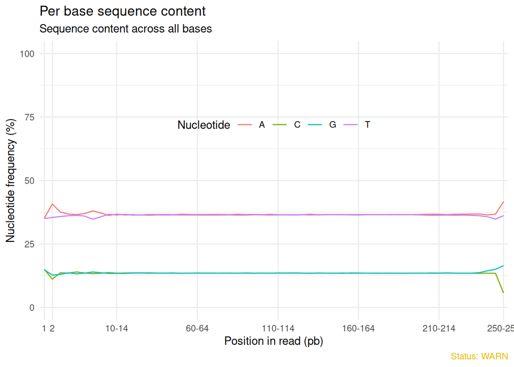

```r
qc_plot(qc, "Per base sequence content")
```

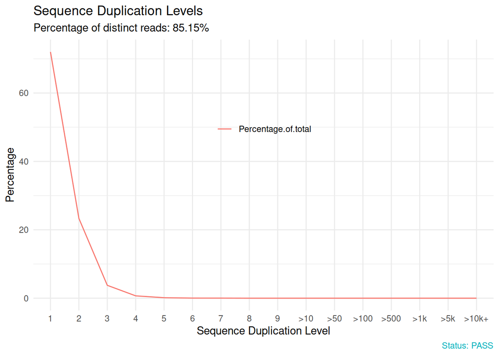

```r
qc_plot(qc, "Sequence duplication levels")
```

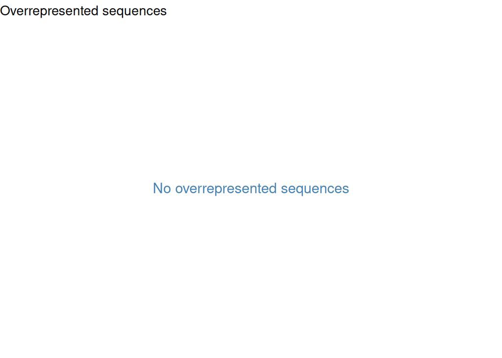

```r
qc_plot(qc, "Overrepresented sequences")
```

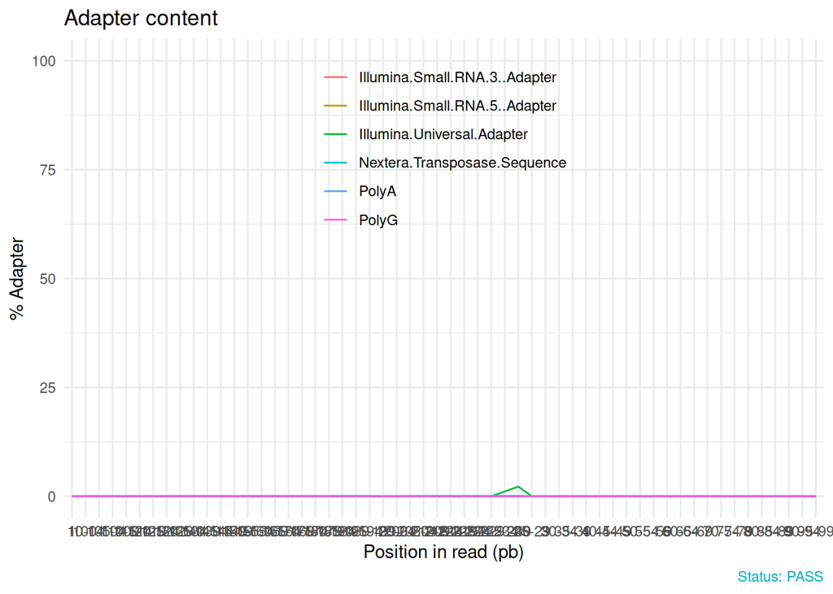

```r
qc_plot(qc, "Adapter content")
```

```r
#qc_plot(qc, "Kmer content")
```

## Filtrado de lecturas de archivos FASTQ

En esta sección, se realiza el filtrado de lecturas de los archivos FASTQ utilizando la función `filter_reads` previamente definida:

```r
log_filter <- filter_reads(name = lecturas$name, lf = lecturas$lf,
             lr = lecturas$lr, trunc = 250)
```

El código ejecuta la función `filter_reads` en las lecturas previamente listadas, aplicando un valor de truncamiento de 250. El registro del filtrado se almacena en la variable `log_filter`.

## Ensamblaje de genomas

En esta sección, se realiza el ensamblaje de genomas utilizando la biblioteca `bowtie2`. Primero, se descomprime el genoma de referencia:

```r
gunzip("data/reference/GCF_000085865.1_ASM8586v1_genomic.fna.gz")
```

Luego, se construye el índice de referencia para `bowtie2`:

```r
bowtie2_build("data/reference/GCF_000085865.1_ASM8586v1_genomic.fna",
              bt2Index = "data/reference/index/myco" , overwrite = TRUE)
```

Finalmente, se realiza el alineamiento de los archivos FASTQ a la referencia utilizando `bowtie2`:

```r
bowtie2(bt2Index = "data/reference/index/myco",
        samOutput = "results/SRR15616379.sam",
        seq1 = "data/processed_data/filtered_F/SRR15616379_filt_1.fastq",
        seq2 = "data/processed_data/filtered_R/SRR15616379_filt_2.fastq",
        "--threads=3")
```

Estos pasos incluyen la construcción del índice de referencia y el alineamiento de las lecturas de secuenciación en los archivos FASTQ a la referencia genómica. El resultado se almacena en un archivo SAM en el directorio `results/`.

## Manipulación de archivos de alineación

En esta sección, se realizan diversas operaciones en archivos de alineación BAM utilizando la biblioteca `Rsamtools`.

### Conversión a archivos BAM

Primero, se convierte el archivo SAM previamente generado en un archivo BAM:

```r
asBam("results/SRR15616379.sam")
```

### Lectura de archivo BAM

Se carga el archivo BAM para realizar estadísticas de alineación:

```r
library(Rsamtools)
bamFile <- BamFile("results/SRR15616379.bam")
```

### Estadísticas de alineación

Se calculan estadísticas de alineación a partir del archivo BAM:

```r
bam <- countBam(bamFile)
quickBamFlagSummary(bamFile)
seqinfo(bamFile)
```

Conteo de profundidad por posición

```r
# count position of alignment
res <- pileup(bamFile)

head(res)
```

```
##      seqnames pos strand nucleotide count
## 1 NC_013511.1   1      +          A     1
## 2 NC_013511.1   1      +          C     1
## 3 NC_013511.1   1      -          C     1
## 4 NC_013511.1   1      +          G     1
## 5 NC_013511.1   1      +          T     6
## 6 NC_013511.1   1      -          T     9
```

```r
table(res$strand, res$nucleotide)
```

```
##
##          A      C      G      T      N      =      -      +
##   + 259168  97674 131968 236724      0      0   4042      0
##   - 239533 127380  97801 256096      0      0   3281      0
##   *      0      0      0      0      0      0      0      0
```

```r
# coverage plot

cover <- res[,c("pos","count")]

#plot(count ~ pos, cover , pch =".")
```

Plot de profundidad

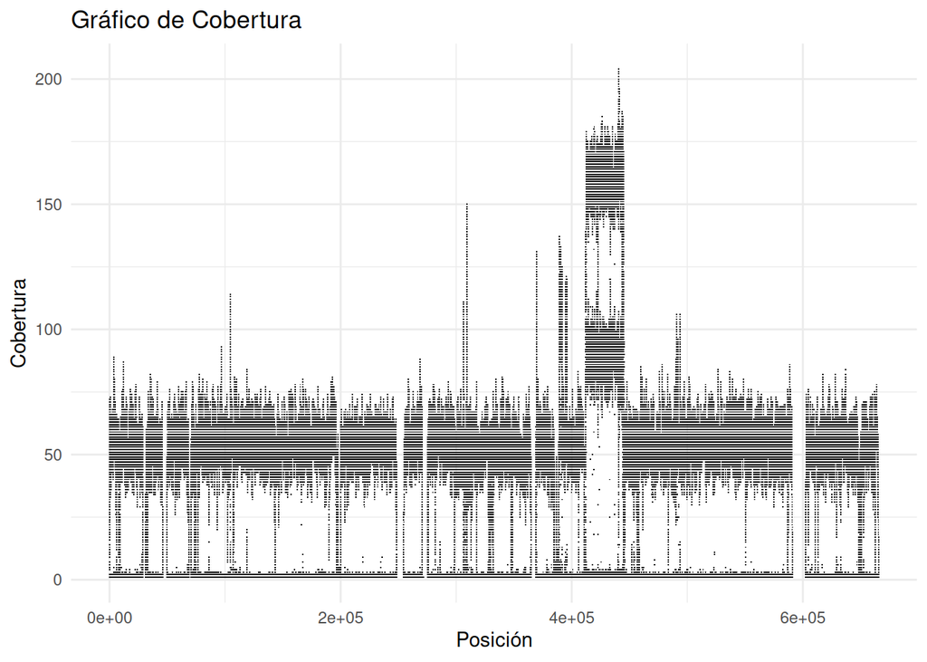

```r
library(ggplot2)
# Crear un gráfico de cobertura utilizando ggplot2
ggplot(cover, aes(x = pos, y = count)) +
  geom_point(shape = ".", size = 1) +
  labs(title = "Gráfico de Cobertura",
       x = "Posición",
       y = "Cobertura") +
  theme_minimal()
```

### Manipulación de archivos BAM de gran tamaño

Se muestra cómo manejar archivos BAM de gran tamaño ajustando el tamaño de lectura:

```r
yieldSize(bamFile) <- 1
open(bamFile)
scanBam(bamFile)[[1]]$seq
close(bamFile)
yieldSize(bamFile) <- NA
```

<Anterior | Siguiente>